# Question

Consider the $L$-system (and turn angle) defined below:

- Start: `A`
- Rules:  
  `A > +++BA----ABA----AB+++`  
  `B > ---AB++++BAB++++BA---`
- Number of recursions (number of iterations):
  - 5
- Turn angle
  - 50°

Please use [this online tool](https://artockthedino.github.io/lsys.html) to generate the pattern using turtle graphics. Choose the matching pattern. (The initial angle should be $270$ degrees to match the orientation.)

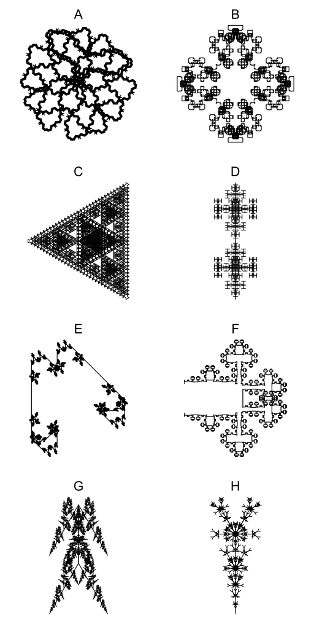

## Answerlist

- A
- B
- C
- D
- E
- F
- G
- H

# Solution

The correct pattern is pattern A.

1. Use the first link: https://artockthedino.github.io/lsys.html
2. Copy/paste the `Axiom`, `Rules`, `Iterations`, and `Turn angle`.
3. Click `Generate Pattern`
4. Back to the quiz, select the matching pattern.

In case you’re interested in the parameters of the other patterns shown:

## Pattern A

- Start: `A`
- Rules:  
  `A > +++BA----ABA----AB+++`  
  `B > ---AB++++BAB++++BA---`
- Number of recursions (number of iterations):
  - 5
- Angle
  - 50

## Pattern B

- Start: `A+A+A+A`
- Rules:  
  `A > +B-ABCBA-B+`  
  `B > -A++B+B++A-`  
  `C > CC`
- Number of recursions (number of iterations):
  - 5
- Angle
  - 90

## Pattern C

- Start: `AAA`
- Rules:  
  `A > A++B-C-B++A`  
  `B > B--A+C+A--B`  
  `C > CC`
- Number of recursions (number of iterations):
  - 6
- Angle
  - 60

## Pattern D

- Start: `AA`
- Rules:  
  `A > ABA`  
  `B > C[-BAB][+BAB]`  
  `C > CC`
- Number of recursions (number of iterations):
  - 5
- Angle
  - 90

## Pattern E

- Start: `A`
- Rules:  
  `A > +B-ACA-ACA-B+`  
  `B > -A+BCB+BCB+A-`  
  `C > CCC`
- Number of recursions (number of iterations):
  - 5
- Angle
  - 135

## Pattern F

- Start: `A`
- Rules:  
  `A > +BA+ACCA+AB+`  
  `B > -C+++BACCAB+++C-`  
  `C > CC`
- Number of recursions (number of iterations):
  - 5
- Angle
  - 90

## Pattern G

- Start: `[+A][-B]`
- Rules:  
  `A > [-CA-CB]CA`  
  `B > [+CB+CA]CB`  
  `C > CC`
- Number of recursions (number of iterations):
  - 6
- Angle
  - 150

## Pattern H

- Start: `A`
- Rules:  
  `A > ADB`  
  `B > [-CA][+CA]`  
  `C > [+C[-A][+A]][-C[-A][+A]]`  
  `D > E`  
  `E > AA`
- Number of recursions (number of iterations):
  - 7
- Angle
  - 30

# Meta-information

extype: schoice exsolution: 10000000 exname: lsys_pattern